# Conceitos estatisticos para IA

# 11 Gráficos de dispersão

Gerando gráficos de dispersão com todas as variáveis que apresentaram algum tipo de relação com a variável que decide a qualidade(quality) dos vinhos

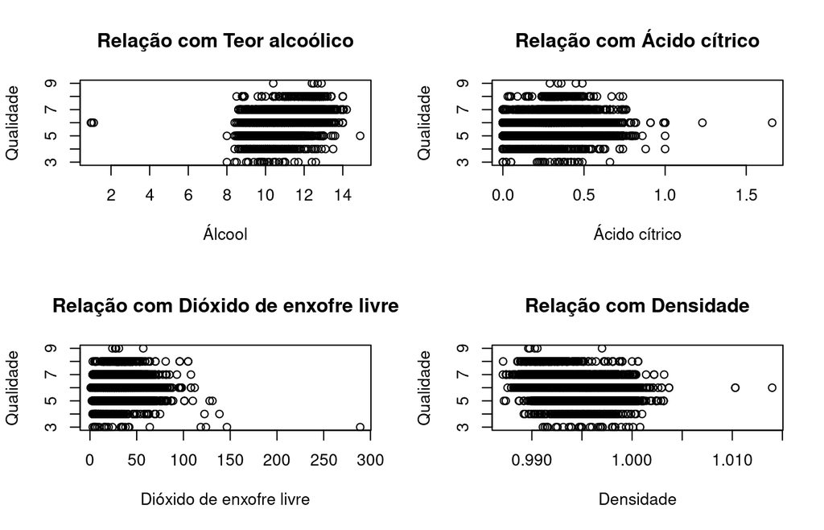

```r
par (mfrow=c(2,2))
plot (x = vinhosret$alcohol, y = vinhosret$quality,
      main = "Relação com Teor alcoólico",
      xlab = "Álcool",
      ylab = "Qualidade")

plot (x = vinhosret$citricacid, y = vinhosret$quality,
      main = "Relação com Ácido cítrico",
      xlab = "Ácido cítrico",
      ylab = "Qualidade")

plot (x = vinhosret$freesulfurdioxide, y = vinhosret$quality,
      main = "Relação com Dióxido de enxofre livre",
      xlab = "Dióxido de enxofre livre",
      ylab = "Qualidade")

plot (x = vinhosret$density, y = vinhosret$quality,
      main = "Relação com Densidade",
      xlab = "Densidade",
      ylab = "Qualidade")
```

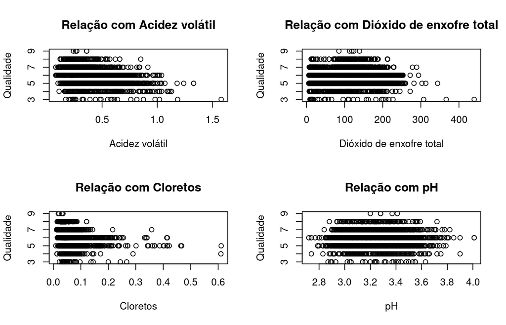

```r
plot (x = vinhosret$volatileacidity, y = vinhosret$quality,
      main = "Relação com Acidez volátil",
      xlab = "Acidez volátil",
      ylab = "Qualidade")

plot (x = vinhosret$totalsulfurdioxide, y = vinhosret$quality,
      main = "Relação com Dióxido de enxofre total",
      xlab = "Dióxido de enxofre total",
      ylab = "Qualidade")

plot (x = vinhosret$chlorides, y = vinhosret$quality,
      main = "Relação com Cloretos",
      xlab = "Cloretos",
      ylab = "Qualidade")

plot (x = vinhosret$pH, y = vinhosret$quality,
      main = "Relação com pH",
      xlab = "pH",
      ylab = "Qualidade")
```

# 12 Criando massa de teste e treino

Para esse passo, separamos 70% da base como modelo de aprendizagem para treinar os algoritmos e 30% da base como modelo de testes, para validarmos se os algoritmos possuem assertividade

```r
set.seed(1337)
indice_vinho <- createDataPartition(vinhosret$quality, p=0.7, list=F)
treino <- as.data.frame(vinhosret[indice_vinho, ])
teste <- as.data.frame(vinhosret[-indice_vinho, ])
```

# 13 Regressão linear

Primeiramente vamos executar um algoritmo de regressão linear, com o intuito de iniciar o processo de estimar a variavel quality

```r
model <- lm(treino$quality ~ treino$freesulfurdioxide+treino$totalsulfurdioxide+treino$density+treino$chlorides+treino$alcohol+treino$sulphates+treino$volatileacidity+treino$density)
summary(model)
```

```
##
## Call:
## lm(formula = treino$quality ~ treino$freesulfurdioxide + treino$totalsulfurdioxide +
##     treino$density + treino$chlorides + treino$alcohol + treino$sulphates +
##     treino$volatileacidity + treino$density)
##
## Residuals:
##     Min      1Q  Median      3Q     Max
## -4.1175 -0.4662 -0.0416  0.4747  3.4840
##
## Coefficients:
##                             Estimate Std. Error t value Pr(>|t|)
## (Intercept)               -1.504e+01  5.703e+00  -2.637  0.00840 **
## treino$freesulfurdioxide   7.042e-03  8.887e-04   7.924 2.88e-15 ***
## treino$totalsulfurdioxide -2.144e-03  3.035e-04  -7.065 1.85e-12 ***
## treino$density             1.797e+01  5.657e+00   3.177  0.00150 **
## treino$chlorides          -1.451e+00  3.749e-01  -3.871  0.00011 ***
## treino$alcohol             3.137e-01  1.355e-02  23.147  < 2e-16 ***
## treino$sulphates           5.947e-01  8.464e-02   7.026 2.45e-12 ***
## treino$volatileacidity    -1.505e+00  7.935e-02 -18.963  < 2e-16 ***
## ---
## Signif. codes:  0 '***' 0.001 '**' 0.01 '*' 0.05 '.' 0.1 ' ' 1
##
## Residual standard error: 0.7435 on 4541 degrees of freedom
## Multiple R-squared:  0.2773, Adjusted R-squared:  0.2762
## F-statistic: 248.9 on 7 and 4541 DF,  p-value: < 2.2e-16
```

```r
val_pred <- predict(model, newdata=teste, interval = 'prediction', level = 0.80)
summary(val_pred)
```

```
##       fit             lwr             upr
##  Min.   :2.516   Min.   :1.548   Min.   :3.484
##  1st Qu.:5.487   1st Qu.:4.533   1st Qu.:6.440
##  Median :5.812   Median :4.857   Median :6.766
##  Mean   :5.817   Mean   :4.863   Mean   :6.770
##  3rd Qu.:6.153   3rd Qu.:5.200   3rd Qu.:7.106
##  Max.   :7.386   Max.   :6.429   Max.   :8.344
```

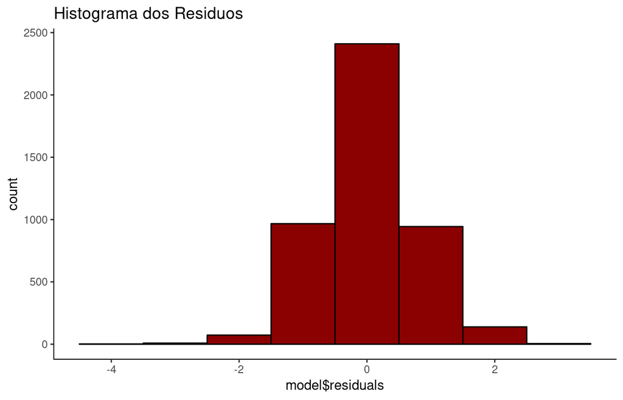

```r
ggplot(data=model, aes(model$residuals)) +
geom_histogram(binwidth = 1, color = "black", fill = "red4") +
theme(panel.background = element_rect(fill = "white"),
axis.line.x=element_line(),
axis.line.y=element_line()) +
ggtitle("Histograma dos Residuos")
```

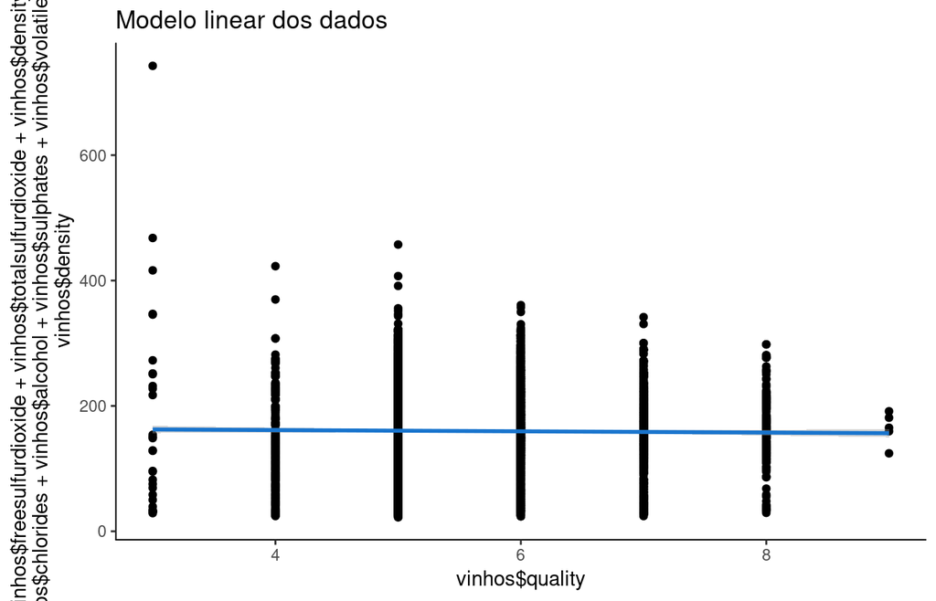

```r
ggplot(data = vinhos, aes(x = vinhos$quality, y = vinhos$freesulfurdioxide+vinhos$totalsulfurdioxide+vinhos$density+vinhos$chlorides+vinhos$alcohol+vinhos$sulphates+vinhos$volatileacidity+vinhos$density)) +
geom_point() +
stat_smooth(method = "lm", col = "dodgerblue3") +
theme(panel.background = element_rect(fill = "white"),
axis.line.x=element_line(),
axis.line.y=element_line()) +
ggtitle("Modelo linear dos dados")
```